# dburow_finalproj

Hurricane Florence made landfall near Wrightsville Beach, North Carolina, on 14 September 2018 (Stewart and Berg 2019). Florence moved very slowly through the region, and its long residence time allowed for extreme precipitation totals that exceeded 20 inches in much of the coastal North Carolina region. Precipitation pulses such as this one affect the hydrological cycle by washing organic matter and increasing runoff into local rivers (Raymond et al. 2016; Chen et al. 2019).

Here, I use MODIS imagery of red band reflectance to examine spectral changes in the waters offshore of Cape Hatteras. Red reflectance has been used in studies such as Miller and McKee (2004) to measure suspended particulate matter, and as a key variable in turbidity calculations in the coastal Southeast by Joshi et al. (2017). MODIS imagery has a spatial resolution of 250 meters in the visible spectrum, and a one-day temporal resolution.

I used four separate images of the Atlantic Ocean within 150 kilometers of Cape Hatteras for this procedure. Two of them were composite images compiled by NASA over eight consecutive days (22 September to 30 September and 08 October to 16 October) with the goal of representing cloud-free conditions over these eight-day two eight day spans. The other two images were single-day images obtained on 27 September and 13 October, days that had few clouds in the region. None of the four regions are completely free from cloud contamination, so I applied a simple mask to exclude pixels with red reflectance greater than 0.10, because it is very unlikely for sea water to exhibit reflectance of this value in the red band, while cloudy regions tend to have greater red reflectance values than this. Portable network graphic (.png) files of difference images derived from the two compsite images can be found at: https://github.com/dburow/GEOL590final/blob/master/compositediffmap.png and from the single-day images at: https://github.com/dburow/GEOL590final/blob/master/singledaydiffmap.png.

```r
#Produces combined histogram of red reflectance changes derived from composite imagery and single day imagery
#BEFORE RUNNING:
```

```
#> uncomment package installation as needed
#> correct filepaths for TIFFs
```

```r
##install.packages("ggplot2")
##install.packages("raster")
library(ggplot2)
library(raster)
#Filepaths in following two lines will need to be changed as needed
change1 <- raster(x = "C:/Users/danie/Downloads/GEOL590/finalproj/tiffs/compositediff.tif")#filepath for composite tif
change2 <- raster(x = "C:/Users/danie/Downloads/GEOL590/finalproj/tiffs/singledaydiff.tif")#filepath for single-day tif
#Define rasters as data frames makes them work in ggplot
change1_df <- as.data.frame(values(change1))
change2_df <- as.data.frame(values(change2))

#There's lots of null values in each raster that need to be omitted
df_values1 <- na.omit(change1_df)
df_values2 <- na.omit(change2_df)

#put values into column with same name so rbind works
df_values1$value <- df_values1$`values(change1)`
df_values2$value <- df_values2$`values(change2)`


#select value column to get rid of values(change1) column that messes up rbind
df_filter1 <- subset(df_values1, value < 1000, select = c("value"))
df_filter2 <- subset(df_values2, value < 1000, select = c("value"))

#we need to cast them as strings apparently
str(df_filter1)
```

```
## 'data.frame':    69809 obs. of  1 variable:
##  $ value: int  -29 -26 -38 -11 16 -15 55 26 25 16 ...
```

```r
str(df_filter2)
```

```
## 'data.frame':    69239 obs. of  1 variable:
##  $ value: int  -29 -26 -38 -11 16 -15 -26 -52 25 16 ...
```

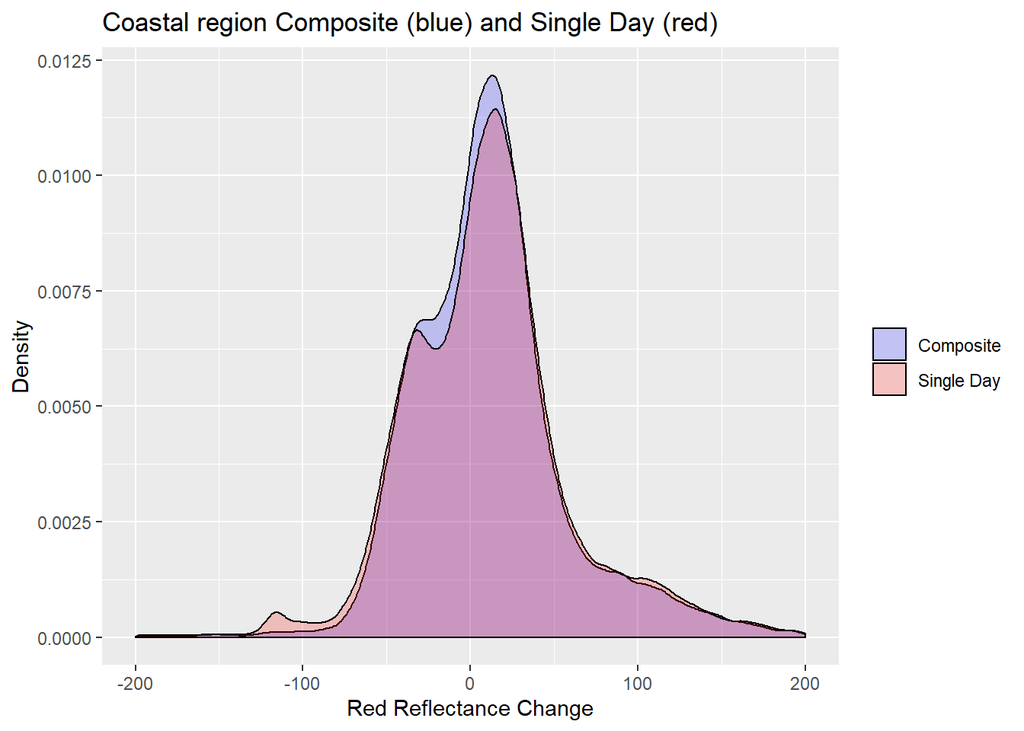

```r
#Define a variable that will differentiate them after rbind
df_filter1$timestep <- "Composite"
df_filter2$timestep <- "Single Day"

#combine data into single object
allchange <- rbind(df_filter1, df_filter2)

#density histogram
combhist <- ggplot(allchange, aes(value, fill = timestep)) + geom_density(alpha=0.2)

#color code and label appropriately
#Few change values exist beyond 200 on x axis
combhist + scale_fill_manual(breaks = c("Composite", "Single Day"),
                             values=c("blue", "red")) +
  ggtitle("Coastal region Composite (blue) and Single Day (red)") +
  xlab("Red Reflectance Change") +
  ylab("Density") +
  xlim(-200, 200) +
  theme(legend.title = element_blank())
```

A majority of the values are above zero, and both distributions are skewed right, suggesting that red reflectance tended to increase following Florence in the region. Many of the negative values are found further offshore, where the ocean is deeper and sediment discharge mixes out quickly. The histograms are very similar, but neither are truly unimodal. A limitation of using composite images is that, while generally cloud-free, two neighboring pixels may have been obtained from any of the eight days in the composite, which is notable in examining changes over the scale of weeks. I compared spatial autocorrelation in the two difference images by creating empirical semivariograms of the rasters. The code can be found in the following two chunks.

```r
#Creates empirical semivariogram of raster values
#BEFORE RUNNING:
```

```
#> Uncomment package installation as needed
#> Correct filepath as needed
#> Run section one first
#> Then correct nrow value using summary output; run balance of code
```

```r
#SECTION ONE FOR SEMIVARIOGRAM
##install.packages("gstat")
library(gstat)
#correct filepath below as needed
changerast <- raster(x = "C:/Users/danie/Downloads/GEOL590/finalproj/tiffs/compositediff.tif")#filepath for desired tiff (composite or single-day)

#Need dataframe for semivariogram
spatialpoints <- as(changerast, 'SpatialPointsDataFrame')
#There are na values in dataframe from masked out pixels
spatialpoints <- na.omit(spatialpoints)
#Summary command displays how many values there are in the raster
#Will need this number below
summary(spatialpoints)
```

```
## Object of class SpatialPointsDataFrame
## Coordinates:
##        min      max
## x -7007836 -6777570
## y  3772987  3971285
## Is projected: TRUE
## proj4string :
## [+proj=sinu +lon_0=0 +x_0=0 +y_0=0 +a=6371007.181 +b=6371007.181
## +units=m +no_defs]
## Number of points: 69813
## Data attributes:
##  compositediff
##  Min.   :-1031.000
##  1st Qu.:  -18.000
##  Median :    9.000
##  Mean   :    9.652
##  3rd Qu.:   31.000
##  Max.   : 1083.000
```

The summary command displays how many values there are in the raster. The composite and single-day difference images have a different number of pixels in them because of the cloud mask I applied. This values needs to be fixed in the first line of runnable code below (nrow = x).

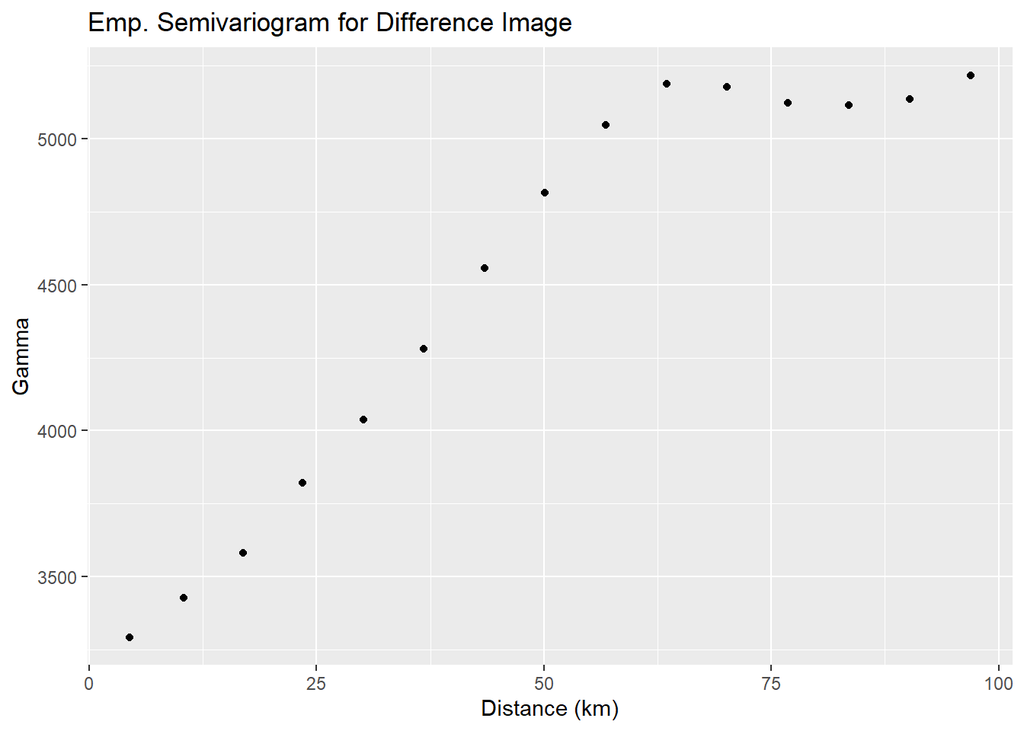

```r
#SECTION TWO FOR SEMIVARIOGRAM
#create new data frame with lat/lon data in km rather than degrees
#nrow value before should be equal to the number of values in the raster found above
#Correct title of plot in ggplot as needed (single day vs. difference)
spatialpointskm <- data.frame(matrix(nrow = 69813))
#1 deg lat is ~110 km worldwide
spatialpointskm$y <- 110.*(spatialpoints$y-3800000)/100000
#1 deg lon is ~90 km at this latitude
spatialpointskm$x <- 90.*(spatialpoints$x + 7000000)/100000
#z variable remains unchanged
spatialpointskm$deltaref <- spatialpoints$compositediff

#create and display variogram
thevariogram <- variogram(deltaref~1, loc= ~x + y, data = spatialpointskm)
ggplot(thevariogram, aes(x = dist, y = gamma)) +
  geom_point() +
  xlab("Distance (km)") +
  ylab("Gamma") +
  ggtitle("Emp. Semivariogram for Difference Image")
```

A combined png of both semivariograms can be found at https://github.com/dburow/GEOL590final/blob/master/variograms_comb.png. The gamma values for both semivariograms level off at a distance of about 60 kilometers, suggesting that strong autocorrelation is found at distances less than this. The histograms are also similar. These findings suggest that using composite images for this analysis does not play a substantial role in altering the difference maps shown at https://github.com/dburow/GEOL590final/blob/master/compositediffmap.png and https://github.com/dburow/GEOL590final/blob/master/singledaydiffmap.png. This may be because the composite images drew heavily from the single-day 27 Sept and 13 Oct images, which exhibited the least cloud-contamination in each composite.

REFERENCES:

Chen, S., Y. Lu, P. Dash, P. Das, J. Li, K. Capps, H. Majidzadeh, and M. Elliot. 2019. Hurricane pulses: Small watershed exports of dissolved nutrients and organic matter during large storms in the Southeastern USA. *Science of the Total Environment*. 689:232-244.

Joshi, I., E. D’Sa, C. Osburn, and T. Bianchi. 2017. Turbidity in Apalachicola Bay, Florida from Landsat 5 TM and field data: Seasonal patterns and response to extreme events. *Remote Sensing*. 9:367.

Miller, R., and B. McKee. 2004. Using MODIS Terra 250 m imagery to map concentrations of total suspended matter in coastal waters. *Remote Sensing of the Environment*. 93:259-266.

Raymond, P., J. Saiers, and W. Sobczak. 2016. Hydrological and biogeochemical controls on watershed dissolved organic matter transport: Pulse-shunt concept. *Ecology*. 97:5-16.

Stewart, S., and R. Berg. “National Hurricane Center Tropical Cyclone Report: Hurricane Florence”. 30 May 2019. Available online at: https://www.nhc.noaa.gov/data/tcr/AL062018_Florence.pdf